# "Smart" Gesture Recognition

**Business Proposal**

Nowadays, technology has a pivotal role in creating virtual environments with virtual elements. We work collaboratively with real-world intelligent objects on a day-to-day basis. Innovations like the Internet of things (IoT) products, gesture recognition, and teleportation application have certainly made our life "smarter" and more accessible.

Embracing an "implementing a smarter life" mindset, Team College aims to develop a cool feature in the smart TV that can recognize five different gestures performed by the user to help users control the TV without using a remote. Based on this dataset, Team College wants to develop a well-rounded deep learning gesture recognition model which has applications in a spectrum of different industries beyond smart-TV.

**Dataset Description** The data consists of a few hundred videos categorized into five classes: thumb up, thumb down, swipe left, swipe right, stop. The webcam mounted on the TV continuously monitors the gestures. Each motion corresponds to a specific command:

| Gesture | Corresponding Action |
| --- | --- |
| Thumbs Up | Increase the volume. |
| Thumbs Down | Decrease the volume. |
| Left Swipe | 'Jump' backwards 10 seconds. |
| Right Swipe | 'Jump' forward 10 seconds. |
| Stop | Pause the movie. |

The training data consists of 19,890 images (663*30): there are 663 videos categorized into one of the five classes. Each video (typically 2-3 seconds long) is divided into a sequence of 30 frames(images). The testing data consists of a total of 3,000 images.

Various people have recorded these videos performing one of the five gestures in front of a webcam - like what the smart TV will use. Specifically, videos have two types of dimensions - either 360x360 or 120x160 (depending on the webcam used to record the videos)

### Team College Objectives:

1. **Data Preprocessing_Generator Establishment**: Team College aim to build a function called "Generator" so that this fuction should be able to take a batch of videos as input without any error. Steps like cropping, resizing and normalization should be performed successfully.
2. **Experimentation _ Model Architecture**: Team College aim to develop the best model that is able to train with high accuracy and without any errors. To achieve the goal, Conv3D with Maxpolling 3D, RNN, CNN LSTM with GRU (for augmentation) models will be used to tackle the problem.
3. **Best Performing Model**: Further Development and Tryouts such as Generative Adversarial Networks (GAN) , Different Batch Size, Learning Rate and tansfer learning method will be applied to design the best performing Model.

```python
#!pip install opencv-python

#bash
#git clone https://github.com/brohrer/lodgepole.git
!pip install -e lodgepole
#!pip install -e lodgepole.image_tools
```

```
Obtaining file:///C:/Users/deepa/MMAI894/MMAI894/lodgepole
  Attempting uninstall: lodgepole
    Found existing installation: lodgepole 3
    Uninstalling lodgepole-3:
      Successfully uninstalled lodgepole-3
  Running setup.py develop for lodgepole
```

## Housekeeping Setup

```python
import numpy as np
import pandas as pd
from sklearn.model_selection import train_test_split
from keras.models import Sequential, Model
from keras.layers import Dense, Dropout, Conv2D, MaxPooling2D, Flatten, Activation, LSTM
from keras.layers.convolutional import Conv3D, MaxPooling3D, Conv2D, MaxPooling2D
from keras.utils import np_utils
from tensorflow.keras.utils import to_categorical
from matplotlib import image

import os
from skimage.transform import resize
from imageio import imread
import datetime

import pathlib
from os.path import isfile, join

import matplotlib.pyplot as plt
import PIL
import PIL.Image
import warnings
warnings.filterwarnings('ignore')

from skimage import color
from skimage import io
from skimage import img_as_float
import cv2
from PIL import Image
#import lodgepole.image_tools as lit
#import lodgepole
```

We set the random seed as 30 to ensure the steady outcome

```python
import datetime
np.random.seed(30)
import random as rn
rn.seed(30)
from keras import backend as K
import tensorflow as tf
from tensorflow import keras
tf.random.set_seed(30)

import torch
import torch.nn as nn
```

Setp for GPU check, if you have it, lucky you; ifelse, this might take some time to compute :)

```python
import tensorflow as tf
print("Num GPUs Available: ", len(tf.config.list_physical_devices('GPU')))
```

```
Num GPUs Available:  0
```

## Load Data

- No. training sequences = 530
- No. validation sequences = 133
- No. testing sequences = 100

train-val-test = 70% - 17% -13%

```python
train_doc = np.random.permutation(open('Project_data/train.csv').readlines())
test_doc = np.random.permutation(open('Project_data/test.csv').readlines())
val_doc = np.random.permutation(open('Project_data/val.csv').readlines())
batch_size = 64
```

## Data EDA

Sample train and val dataset display as follow:

```python
train_doc
```

[output not shown]

[output cut: 476 more lines]

```
       'WIN_20180907_16_06_43_Pro_Stop Gesture_new,Stop Gesture_new,2\n',
       'WIN_20180926_17_07_57_Pro_Thumbs_Up_new,Thumbs_Up_new,4\n',
       'WIN_20180926_16_50_28_Pro_Right_Swipe_new,Right_Swipe_new,1\n',
       'WIN_20180925_17_51_26_Pro_Left_Swipe_new,Left_Swipe_new,0\n',
       'WIN_20180925_17_42_57_Pro_Stop_new,Stop_new,2\n',
       'WIN_20180907_15_43_40_Pro_Stop Gesture_new,Stop Gesture_new,2\n',
       'WIN_20180926_16_39_58_Pro_Thumbs_Down_new,Thumbs_Down_new,3\n',
       'WIN_20180907_15_59_44_Pro_Right Swipe_new,Right Swipe_new,1\n',
       'WIN_20180926_17_20_04_Pro_Right_Swipe_new,Right_Swipe_new,1\n',
       'WIN_20180907_16_17_00_Pro_Right Swipe_new,Right Swipe_new,1\n',
       'WIN_20180926_17_44_20_Pro_Right_Swipe_new,Right_Swipe_new,1\n',
       'WIN_20180926_17_36_34_Pro_Right_Swipe_new,Right_Swipe_new,1\n',
       'WIN_20180907_15_40_55_Pro_Thumbs Up_new,Thumbs Up_new,4\n',
       'WIN_20180907_15_49_56_Pro_Right Swipe_new,Right Swipe_new,1\n'],
      dtype='<U88')
```

```python
val_doc
```

[output not shown]

[output cut: 79 more lines]

```
       'WIN_20180925_17_50_17_Pro_Thumbs_Down_new,Thumbs_Down_new,3\n',
       'WIN_20180907_16_14_53_Pro_Stop Gesture_new,Stop Gesture_new,2\n',
       'WIN_20180926_17_40_52_Pro_Right_Swipe_new,Right_Swipe_new,1\n',
       'WIN_20180926_17_21_20_Pro_Right_Swipe_new,Right_Swipe_new,1\n',
       'WIN_20180926_17_35_35_Pro_Thumbs_Down_new,Thumbs_Down_new,3\n',
       'WIN_20180907_16_12_20_Pro_Right Swipe_new,Right Swipe_new,1\n',
       'WIN_20180926_17_27_48_Pro_Thumbs_Up_new,Thumbs_Up_new,4\n',
       'WIN_20180925_17_50_44_Pro_Left_Swipe_new,Left_Swipe_new,0\n',
       'WIN_20180925_17_43_33_Pro_Thumbs_Down_new,Thumbs_Down_new,3\n',
       'WIN_20180926_17_30_24_Pro_Right_Swipe_new,Right_Swipe_new,1\n',
       'WIN_20180926_16_48_32_Pro_Thumbs_Up_new,Thumbs_Up_new,4\n',
       'WIN_20180926_17_10_34_Pro_Right_Swipe_new,Right_Swipe_new,1\n',
       'WIN_20180926_17_35_12_Pro_Thumbs_Down_new,Thumbs_Down_new,3\n',
       'WIN_20180926_17_15_12_Pro_Left_Swipe_new,Left_Swipe_new,0\n'],
      dtype='<U88')
```

```python
test_doc
```

[output not shown]

[output cut: 46 more lines]

```
       'WIN_20180926_17_12_27_Pro_Right_Swipe_new;Right_Swipe_new;1\n',
       'WIN_20180925_17_32_32_Pro_Stop_new;Stop_new;2\n',
       'WIN_20180907_16_30_54_Pro_Stop Gesture_new;Stop Gesture_new;2\n',
       'WIN_20180907_16_20_15_Pro_Stop Gesture_new;Stop Gesture_new;2\n',
       'WIN_20180907_15_45_04_Pro_Left Swipe_new_Left Swipe_new;Left Swipe_new_Left Swipe_new;0\n',
       'WIN_20180907_16_25_44_Pro_Stop Gesture_new;Stop Gesture_new;2\n',
       'WIN_20180926_17_13_25_Pro_Thumbs_Down_new;Thumbs_Down_new;3\n',
       'WIN_20180907_16_21_39_Pro_Left Swipe_new_Left Swipe_new;Left Swipe_new_Left Swipe_new;0\n',
       'WIN_20180925_17_35_29_Pro_Thumbs_Down_new;Thumbs_Down_new;3\n',
       'WIN_20180925_17_33_30_Pro_Thumbs_Down_new;Thumbs_Down_new;3\n',
       'WIN_20180926_17_34_05_Pro_Right_Swipe_new;Right_Swipe_new;1\n',
       'WIN_20180907_16_05_10_Pro_Right Swipe_new;Right Swipe_new;1\n',
       'WIN_20180907_15_50_39_Pro_Right Swipe_new;Right Swipe_new;1\n',
       'WIN_20180907_16_05_32_Pro_Left Swipe_new_Left Swipe_new;Left Swipe_new_Left Swipe_new;0\n'],
      dtype='<U88')
```

## Data Preprocessing

Following steps are followed:

1. Resized the image and cropped smaller image shape at center for 120*120
2. Normalized Images
3. Built 3D and 2D filter function
4. Established function to get batch data for preprocessing Convo3D

```python
def cropResize(image, y, z):
    h, w = image.shape
    #image = color.rgb2gray(image)
    # if smaller image crop at center for 120x120
    if w == 160:
        image = image[:120, 20:140]

    # resize every image
    return resize(image, (y,z))
```

```python
def normalizeImage(image):
    # applying normalization
    return image/255.0
```

```python
def preprocessImage(image, y, z):
    image = normalizeImage(cropResize(image, y, z))
    #cv2.cvtColor(image, cv2.COLOR_BGR2GRAY)
    #coeffs = np.array([0.114, 0.587, 0.229])
    #images_gray = (image.astype(np.float) * coeffs).sum(axis=-1, keepdims=True)
    #images_gray = images_gray.astype(image.dtype)
    #images_gray = np.zeros(image.shape[:-1], dtype=image.dtype)
    #images_gray = cv2.cvtColor(image, cv2.COLOR_BGR2GRAY)
    #images_gray  = image[:, :, 0]
    #for i, img in enumerate(image):
    #   images_gray[i] = cv2.cvtColor(img, cv2.COLOR_BGR2GRAY)
    return image
```

```python
def GrayscaleImage(image):
    #read_image = io.imread('demo-image.jpg')
    #img = color.rgb2gray(image)
    # Only convert image to grayscale if RGB
    #if image.shape[-1] == 3:
    #    image = color.rgb2gray(image)
    #image = cv2.cvtColor(image,cv2.COLOR_BGR2GRAY)
    #image= image[:, :, 0]

    return image
```

```python
def make3dFilter(x):
    return tuple([x]*3)

def make2dFilter(x):
    return tuple([x]*2)
```

#### getBatchData For windows?

```python
def getBatchData(source_path, t, batch, batch_size, img_tensor):
    [x,y,z] = [len(img_tensor[0]),img_tensor[1], img_tensor[2]]
    img_idx = img_tensor[0]
    batch_data = np.zeros((batch_size,x,y,z,3)) # x is the number of images you use for each video, (y,z) is the final size of the input images and 3 is the number of channels RGB
    batch_labels = np.zeros((batch_size,5)) # batch_labels is the one hot representation of the output
    for folder in range(batch_size): # iterate over the batch_size
        imgs = os.listdir(source_path+'/'+ t[folder + (batch*batch_size)].split(',')[0]) # read all the images in the folder
        for idx,item in enumerate(img_idx): #  Iterate iver the frames/images of a folder to read them in
            image = cv2.imread(source_path+'/'+ t[folder + (batch*batch_size)].strip().split(',')[0]+'/'+imgs[item],0).astype(np.float32)


            # separate preprocessImage function is defined for cropping, resizing and normalizing images
            batch_data[folder,idx,:,:,0] = preprocessImage(image[:, :], y, z)
            batch_data[folder,idx,:,:, 1] = preprocessImage(image[:, :], y, z)
            batch_data[folder,idx,:,:, 2] = preprocessImage(image[:, :], y, z)


        batch_labels[folder, int(t[folder + (batch*batch_size)].strip().split(',')[2])] = 1
    return batch_data, batch_labels
```

## Generator Establishment

Since the dataset contains 2 types of dimensions, a "generator" is build to preprocess the images for `2D` and `3D` dimensions, as well as create `a batch of video frames`. We experiment with `img_idx`, `y`,`z` and normalization such that to achieve a high accuracy outcome.

```python
def generator(source_path, folder_list, batch_size, img_tensor):
    print( 'Source path = ', source_path, '; batch size =', batch_size)
    while True:
        t = np.random.permutation(folder_list)
        num_batches = int(len(folder_list)/batch_size)
        for batch in range(num_batches): # we iterate over the number of batches
            yield getBatchData(source_path, t, batch, batch_size, img_tensor)

        # write the code for the remaining data points which are left after full batches
        # checking if any remaining batches are there or not
        if len(folder_list)%batch_size != 0:
            # updated the batch size and yield
            batch_size = len(folder_list)%batch_size
            yield getBatchData(source_path, t, batch, batch_size, img_tensor)
```

Note: a video is represented above in the generator as (number of images, height, width, number of channels)

```python
base_dir = os.getcwd()
curr_dt_time = datetime.datetime.now()
train_path = base_dir+'/Project_data/train'
val_path = base_dir+'/Project_data/val'
test_path = base_dir+'/Project_data/test'
num_train_sequences = len(train_doc)
print('# training sequences =', num_train_sequences)
num_val_sequences = len(val_doc)
print('# validation sequences =', num_val_sequences)
num_test_sequences = len(test_doc)
print('# Test sequences =', num_test_sequences)
num_epochs = 10
print ('# epochs =', num_epochs)
```

```
# training sequences = 530
# validation sequences = 133
# Test sequences = 100
# epochs = 10
```

```python
def getImgTensor(n_frames):
    img_idx = np.round(np.linspace(0, 29, n_frames)).astype(int)
    return [img_idx, 100, 100, 3]

# define image tensor size
img_tensor = getImgTensor(20)
print ('# img_tensor =', img_tensor)
```

```
# img_tensor = [array([ 0,  2,  3,  5,  6,  8,  9, 11, 12, 14, 15, 17, 18, 20, 21, 23, 24,
       26, 27, 29]), 100, 100, 3]
```

### Generator Validation

```python
# check complete batch shape
sample_generator = generator(train_path, train_doc, batch_size, img_tensor)
sample_batch_data, sample_batch_labels = next(sample_generator)
print(sample_batch_data.shape)

# validation batch sample
sample_val_generator = generator(val_path, val_doc, batch_size, img_tensor)
sample_val_batch_data, sample_val_batch_labels = next(sample_val_generator)
print(sample_val_batch_data.shape)
```

```
Source path =  C:\Users\deepa\MMAI894\MMAI894/Project_data/train ; batch size = 64
(64, 20, 100, 100, 3)
Source path =  C:\Users\deepa\MMAI894\MMAI894/Project_data/val ; batch size = 64
(64, 20, 100, 100, 3)
```

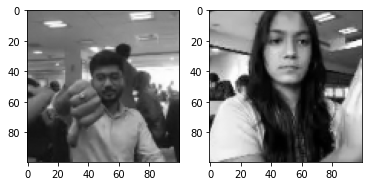

```python
# plot generated sample images
fig, ax = plt.subplots(1,2)
ax[0].imshow(sample_val_batch_data[15,10,:,:,:])
ax[1].imshow(sample_val_batch_data[5,10,:,:,:])
plt.show()
```

```python
def plotModelHistory(h):
    fig, ax = plt.subplots(1, 2, figsize=(15,4))
    ax[0].plot(h.history['loss'])
    ax[0].plot(h.history['val_loss'])
    ax[0].legend(['loss','val_loss'])
    ax[0].title.set_text("Train loss vs Validation loss")

    ax[1].plot(h.history['categorical_accuracy'])
    ax[1].plot(h.history['val_categorical_accuracy'])
    ax[1].legend(['categorical_accuracy','val_categorical_accuracy'])
    ax[1].title.set_text("Train accuracy vs Validation accuracy")
    plt.show()

    print("Max. Training Accuracy", max(h.history['categorical_accuracy']))
    print("Max. Validaiton Accuracy", max(h.history['val_categorical_accuracy']))
```

## Model Building

Team College aim to develop the best model that is able to train with high accuracy and without any errors. To achieve the goal, following Models have been used for tryouts:

1. `Conv3D` with `MaxPooling3D` for a 3D convolution model
2. `TimeDistributed` while building a Conv2D + RNN model
3. `CNN LSTM with GRU` for augmentation

Moreover, for each model, we set the last layer is the softmax so that the least number of parameters can fit in the memory of the webcam. Hence to perform a good accuracy on the least number of parameters.

```python
from keras.models import Sequential, Model
from keras.layers import Dense, GRU, Flatten, TimeDistributed, Flatten, BatchNormalization, Activation, Dropout, LSTM
from keras.layers.convolutional import Conv3D, MaxPooling3D, Conv2D, MaxPooling2D
from keras.callbacks import ModelCheckpoint, ReduceLROnPlateau,CSVLogger,LearningRateScheduler
from keras import optimizers
```

### Base Model

```python
#write your model here
def defineModel(img_tensor):

    opt = tf.keras.optimizers.Adam()

    inputShape = (len(img_tensor[0]), img_tensor[1], img_tensor[2], img_tensor[3])

    model = Sequential([
        Conv3D(16, make3dFilter(5), activation='relu', input_shape=inputShape),
        MaxPooling3D(make3dFilter(2), padding='same'),
        BatchNormalization(),

        Conv3D(32, make3dFilter(3), activation='relu'),
        MaxPooling3D(pool_size=(1,2,2), padding='same'),
        BatchNormalization(),

        Conv3D(64, make3dFilter(3), activation='relu'),
        MaxPooling3D(pool_size=(1,2,2), padding='same'),
        BatchNormalization(),

        Flatten(),
        Dense(128, activation='relu'),
        BatchNormalization(),
        Dropout(0.25),

        Dense(64, activation='relu'),
        BatchNormalization(),
        Dropout(0.25),

        Dense(5, activation='softmax')
    ])
    model.compile(opt, loss='categorical_crossentropy', metrics=['categorical_accuracy'])
    return model

model = defineModel(img_tensor)
model.summary()
```

```
Model: "sequential"
_________________________________________________________________
 Layer (type)                Output Shape              Param #
=================================================================
 conv3d (Conv3D)             (None, 16, 96, 96, 16)    6016

 max_pooling3d (MaxPooling3D  (None, 8, 48, 48, 16)    0
 )

 batch_normalization (BatchN  (None, 8, 48, 48, 16)    64
 ormalization)

 conv3d_1 (Conv3D)           (None, 6, 46, 46, 32)     13856

 max_pooling3d_1 (MaxPooling  (None, 6, 23, 23, 32)    0
 3D)

 batch_normalization_1 (Batc  (None, 6, 23, 23, 32)    128
 hNormalization)

 conv3d_2 (Conv3D)           (None, 4, 21, 21, 64)     55360

 max_pooling3d_2 (MaxPooling  (None, 4, 11, 11, 64)    0
 3D)

 batch_normalization_2 (Batc  (None, 4, 11, 11, 64)    256
 hNormalization)

 flatten (Flatten)           (None, 30976)             0

 dense (Dense)               (None, 128)               3965056

 batch_normalization_3 (Batc  (None, 128)              512
 hNormalization)

 dropout (Dropout)           (None, 128)               0

 dense_1 (Dense)             (None, 64)                8256

 batch_normalization_4 (Batc  (None, 64)               256
 hNormalization)

 dropout_1 (Dropout)         (None, 64)                0

 dense_2 (Dense)             (None, 5)                 325

=================================================================
Total params: 4,050,085
Trainable params: 4,049,477
Non-trainable params: 608
_________________________________________________________________
```

```python
#write your model here
def defineModel(img_tensor):
    inputShape = (len(img_tensor[0]), img_tensor[1], img_tensor[2], img_tensor[3])

    opt = tf.keras.optimizers.Adam()

    model = Sequential([
        Conv3D(16, make3dFilter(5), activation='relu', input_shape=inputShape),
        MaxPooling3D(make3dFilter(2), padding='same'),
        BatchNormalization(),

        Conv3D(32, make3dFilter(3), activation='relu'),
        MaxPooling3D(pool_size=(1,2,2), padding='same'),
        BatchNormalization(),

        Conv3D(64, make3dFilter(3), activation='relu'),
        MaxPooling3D(pool_size=(1,2,2), padding='same'),
        BatchNormalization(),

        Flatten(),
        Dense(128, activation='relu'),
        BatchNormalization(),
        Dropout(0.25),

        Dense(64, activation='relu'),
        BatchNormalization(),
        Dropout(0.25),

        Dense(5, activation='softmax')
    ])
    model.compile(opt, loss='categorical_crossentropy', metrics=['categorical_accuracy'])
    return model

model = defineModel(img_tensor)
model.summary()
```

```
Model: "sequential_1"
_________________________________________________________________
 Layer (type)                Output Shape              Param #
=================================================================
 conv3d_3 (Conv3D)           (None, 16, 96, 96, 16)    6016

 max_pooling3d_3 (MaxPooling  (None, 8, 48, 48, 16)    0
 3D)

 batch_normalization_5 (Batc  (None, 8, 48, 48, 16)    64
 hNormalization)

 conv3d_4 (Conv3D)           (None, 6, 46, 46, 32)     13856

 max_pooling3d_4 (MaxPooling  (None, 6, 23, 23, 32)    0
 3D)

 batch_normalization_6 (Batc  (None, 6, 23, 23, 32)    128
 hNormalization)

 conv3d_5 (Conv3D)           (None, 4, 21, 21, 64)     55360

 max_pooling3d_5 (MaxPooling  (None, 4, 11, 11, 64)    0
 3D)

 batch_normalization_7 (Batc  (None, 4, 11, 11, 64)    256
 hNormalization)

 flatten_1 (Flatten)         (None, 30976)             0

 dense_3 (Dense)             (None, 128)               3965056

 batch_normalization_8 (Batc  (None, 128)              512
 hNormalization)

 dropout_2 (Dropout)         (None, 128)               0

 dense_4 (Dense)             (None, 64)                8256

 batch_normalization_9 (Batc  (None, 64)               256
 hNormalization)

 dropout_3 (Dropout)         (None, 64)                0

 dense_5 (Dense)             (None, 5)                 325

=================================================================
Total params: 4,050,085
Trainable params: 4,049,477
Non-trainable params: 608
_________________________________________________________________
```

```python
train_generator = generator(train_path, train_doc, batch_size, img_tensor)
val_generator = generator(val_path, val_doc, batch_size, img_tensor)
```

The `steps_per_epoch` and `validation_steps` are used by `fit_generator` to decide the number of next() calls it need to make.

```python
if (num_train_sequences%batch_size) == 0:
    steps_per_epoch = int(num_train_sequences/batch_size)
else:
    steps_per_epoch = (num_train_sequences//batch_size) + 1

if (num_val_sequences%batch_size) == 0:
    validation_steps = int(num_val_sequences/batch_size)
else:
    validation_steps = (num_val_sequences//batch_size) + 1
```

### Model Callbacks Setup _ CheckPoint, Earlystop & Tensorboard Callbacks

```python
model_name = 'model_init' + '_' + str(curr_dt_time).replace(' ','').replace(':','_') + '/'

if not os.path.exists(model_name):
    os.mkdir(model_name)

filepath = model_name + 'model-{epoch:05d}-{loss:.5f}-{categorical_accuracy:.5f}.h5'


checkpoint = ModelCheckpoint(
    filepath,
    monitor='val_loss',
    verbose=1,
    save_best_only=True,
    save_weights_only=False,
    save_freq=1,
    mode='auto',
    save_fre='epoch'
)
earlystop = tf.keras.callbacks.EarlyStopping(
    monitor='val_loss',
    min_delta=0.001,
    patience=4,
    verbose=1,
    #min_delta=0,
    mode='auto'
)
tensorboard = tf.keras.callbacks.TensorBoard(
    log_dir = './logs',
    histogram_freq=0,
    batch_size=16,
    write_graph=True,
    write_grads=True,
    write_images=False,
    embeddings_freq=0
)

csvlogger = CSVLogger(
    filename= "training_csv.log",
    separator = ",",
    append = False
)

reduce = ReduceLROnPlateau(
    monitor='val_loss',
    factor=0.1,
    patience=3,
    verbose=1,
    mode='auto'
)

callbacks_list = [checkpoint,tensorboard,csvlogger,reduce]
```

```
WARNING:tensorflow:`write_grads` will be ignored in TensorFlow 2.0 for the `TensorBoard` Callback.
WARNING:tensorflow:`batch_size` is no longer needed in the `TensorBoard` Callback and will be ignored in TensorFlow 2.0.
```

### Test Batch Size & Frames

```python
def testBatchSize(batch_size, n_frames):
    img_tensor = getImgTensor(n_frames)
    print("Using frames as", img_tensor[0])
    global callbacks_list
    num_epochs = 3
    train_generator = generator(train_path, train_doc, batch_size, img_tensor)
    val_generator = generator(val_path, val_doc, batch_size, img_tensor)
    if (num_train_sequences%batch_size) == 0:
        steps_per_epoch = int(num_train_sequences/batch_size)
    else:
        steps_per_epoch = (num_train_sequences//batch_size) + 1

    if (num_val_sequences%batch_size) == 0:
        validation_steps = int(num_val_sequences/batch_size)
    else:
        validation_steps = (num_val_sequences//batch_size) + 1

    model = defineModel(img_tensor)
    model.fit_generator(train_generator, steps_per_epoch=steps_per_epoch, epochs=num_epochs, verbose=1,
                callbacks=callbacks_list, validation_data=val_generator,
                validation_steps=validation_steps, class_weight=None, workers=1, initial_epoch=0)
```

```python
testBatchSize(batch_size=64, n_frames=30)
```

```
Using frames as [ 0  1  2  3  4  5  6  7  8  9 10 11 12 13 14 15 16 17 18 19 20 21 22 23
 24 25 26 27 28 29]
Source path =  C:\Users\deepa\MMAI894\MMAI894/Project_data/train ; batch size = 64
WARNING:tensorflow:Can save best model only with val_loss available, skipping.
WARNING:tensorflow:Can save best model only with val_loss available, skipping.
WARNING:tensorflow:Can save best model only with val_loss available, skipping.
```

```python
testBatchSize(batch_size=64, n_frames=16)
```

```
Using frames as [ 0  2  4  6  8 10 12 14 15 17 19 21 23 25 27 29]
Source path =  C:\Users\deepa\MMAI894\MMAI894/Project_data/train ; batch size = 64
WARNING:tensorflow:Can save best model only with val_loss available, skipping.
WARNING:tensorflow:Can save best model only with val_loss available, skipping.
WARNING:tensorflow:Can save best model only with val_loss available, skipping.
```

```python
testBatchSize(batch_size=32, n_frames=30)
```

```
Using frames as [ 0  1  2  3  4  5  6  7  8  9 10 11 12 13 14 15 16 17 18 19 20 21 22 23
 24 25 26 27 28 29]
Source path =  C:\Users\deepa\MMAI894\MMAI894/Project_data/train ; batch size = 32
WARNING:tensorflow:Can save best model only with val_loss available, skipping.
WARNING:tensorflow:Can save best model only with val_loss available, skipping.
WARNING:tensorflow:Can save best model only with val_loss available, skipping.
```

```python
testBatchSize(batch_size=32, n_frames=16)
```

```
Using frames as [ 0  2  4  6  8 10 12 14 15 17 19 21 23 25 27 29]
Source path =  C:\Users\deepa\MMAI894\MMAI894/Project_data/train ; batch size = 32
WARNING:tensorflow:Can save best model only with val_loss available, skipping.
WARNING:tensorflow:Can save best model only with val_loss available, skipping.
WARNING:tensorflow:Can save best model only with val_loss available, skipping.
```

### Model 1 - Frames-16, Epoc-20

```python
n_frames = 16
num_epochs = 20
batch_size = 64

img_tensor = getImgTensor(n_frames)
train_generator = generator(train_path, train_doc, batch_size, img_tensor)
val_generator = generator(val_path, val_doc, batch_size, img_tensor)

if (num_train_sequences%batch_size) == 0:
    steps_per_epoch = int(num_train_sequences/batch_size)
else:
    steps_per_epoch = (num_train_sequences//batch_size) + 1

if (num_val_sequences%batch_size) == 0:
    validation_steps = int(num_val_sequences/batch_size)
else:
    validation_steps = (num_val_sequences//batch_size) + 1

inputShape = (len(img_tensor[0]), img_tensor[1], img_tensor[2], img_tensor[3])

model1 = Sequential([
    Conv3D(16, make3dFilter(5), activation='relu', input_shape=inputShape),
    MaxPooling3D(make3dFilter(2), padding='same'),
    BatchNormalization(),

    Conv3D(32, make3dFilter(3), activation='relu'),
    MaxPooling3D(pool_size=(1,2,2), padding='same'),
    BatchNormalization(),

    Conv3D(64, make3dFilter(3), activation='relu'),
    MaxPooling3D(pool_size=(1,2,2), padding='same'),
    BatchNormalization(),

    Flatten(),
    Dense(128, activation='relu'),
    BatchNormalization(),
    Dropout(0.25),

    Dense(64, activation='relu'),
    BatchNormalization(),
    Dropout(0.25),

    Dense(5, activation='softmax')
], name="conv_3d1")
model1.compile(optimizer= tf.keras.optimizers.Adam(), loss='categorical_crossentropy', metrics=['categorical_accuracy'])
print(model1.summary())

model1_history = model1.fit_generator(train_generator, steps_per_epoch=steps_per_epoch, epochs=num_epochs, verbose=1,
            callbacks=callbacks_list, validation_data=val_generator,
            validation_steps=validation_steps, class_weight=None, workers=1, initial_epoch=0)
```

```
Model: "conv_3d1"
_________________________________________________________________
 Layer (type)                Output Shape              Param #
=================================================================
 conv3d_18 (Conv3D)          (None, 12, 96, 96, 16)    6016

 max_pooling3d_18 (MaxPoolin  (None, 6, 48, 48, 16)    0
 g3D)

 batch_normalization_30 (Bat  (None, 6, 48, 48, 16)    64
 chNormalization)

 conv3d_19 (Conv3D)          (None, 4, 46, 46, 32)     13856

 max_pooling3d_19 (MaxPoolin  (None, 4, 23, 23, 32)    0
 g3D)

 batch_normalization_31 (Bat  (None, 4, 23, 23, 32)    128
 chNormalization)

 conv3d_20 (Conv3D)          (None, 2, 21, 21, 64)     55360

 max_pooling3d_20 (MaxPoolin  (None, 2, 11, 11, 64)    0
 g3D)

 batch_normalization_32 (Bat  (None, 2, 11, 11, 64)    256
 chNormalization)

 flatten_6 (Flatten)         (None, 15488)             0

 dense_18 (Dense)            (None, 128)               1982592

 batch_normalization_33 (Bat  (None, 128)              512
 chNormalization)

 dropout_12 (Dropout)        (None, 128)               0

 dense_19 (Dense)            (None, 64)                8256

 batch_normalization_34 (Bat  (None, 64)               256
```

[output cut: 22 more lines]

[output not shown]

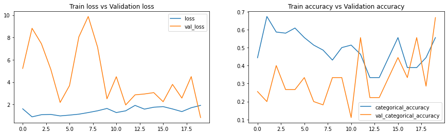

```
Max. Training Accuracy 0.6728395223617554
Max. Validaiton Accuracy 0.6666666865348816
```

```python
plotModelHistory(model1_history)
```

### Model 2: Playground for whatever model you would like to try